# assignment 3 - mark santiago

*Question on Last Page*

# Setting up the Enviorment

```r
library(ISLR)
library(lars)
library(tidyr)
library(readr)
weather_data <- read_csv("NOAAGISSWeatherDisasters.csv")
```

# Drought Model 1

```r
model1_drought <- glm(`Drought Count` ~ delta.temp + Year,
                      data = weather_data,
                      family = binomial(link = "logit"))
```

# Drought Model 2

```r
model2_drought <- glm(`Drought Count` ~ delta.temp * Year,
                      data = weather_data,
                      family = binomial(link = "logit"))
```

# Drought Model 3

```r
model3_drought <- glm(`Drought Count` ~ delta.temp,
                      data = weather_data,
                      family = binomial(link = "logit"))
```

# Drought Model 4

```r
model4_drought <- glm(`Drought Count` ~ Year,
                      data = weather_data,
                      family = binomial(link = "logit"))
```

# Drought Model Summary Statistics

```r
model1_drought
```

```
##
## Call:  glm(formula = `Drought Count` ~ delta.temp + Year, family = binomial(link = "logit"),
##     data = weather_data)
##
## Coefficients:
## (Intercept)   delta.temp         Year
##   -87.14359      1.49853      0.04364
##
## Degrees of Freedom: 43 Total (i.e. Null);  41 Residual
## Null Deviance:       53.41
## Residual Deviance: 46.99     AIC: 52.99
```

```r
model2_drought
```

```
##
## Call:  glm(formula = `Drought Count` ~ delta.temp * Year, family = binomial(link = "logit"),
##     data = weather_data)
##
## Coefficients:
##     (Intercept)       delta.temp             Year  delta.temp:Year
##      -164.34308        181.03552          0.08222         -0.08949
##
## Degrees of Freedom: 43 Total (i.e. Null);  40 Residual
## Null Deviance:       53.41
## Residual Deviance: 46.53     AIC: 54.53
```

```r
model3_drought
```

```
##
## Call:  glm(formula = `Drought Count` ~ delta.temp, family = binomial(link = "logit"),
##     data = weather_data)
##
## Coefficients:
## (Intercept)   delta.temp
##     -0.9172       3.5189
##
## Degrees of Freedom: 43 Total (i.e. Null);  42 Residual
## Null Deviance:       53.41
## Residual Deviance: 47.34     AIC: 51.34
```

```r
model4_drought
```

```
##
## Call:  glm(formula = `Drought Count` ~ Year, family = binomial(link = "logit"),
##     data = weather_data)
##
## Coefficients:
## (Intercept)         Year
##  -141.19884      0.07106
##
## Degrees of Freedom: 43 Total (i.e. Null);  42 Residual
## Null Deviance:       53.41
## Residual Deviance: 47.15     AIC: 51.15
```

# Wildfire Model 1

```r
model1_wildfire <- glm(`Wildfire Count` ~ delta.temp + Year,
                       data = weather_data,
                       family = binomial(link = "logit"))
```

# Wildfire Model 2

```r
model2_wildfire <- glm(`Wildfire Count` ~ delta.temp * Year,
                       data = weather_data,
                       family = binomial(link = "logit"))
```

# Wildfire Model 3

```r
model3_wildfire <- glm(`Wildfire Count` ~ delta.temp,
                       data = weather_data,
                       family = binomial(link = "logit"))
```

# Wildfire Model 4

```r
model4_wildfire <- glm(`Wildfire Count` ~ Year,
                       data = weather_data,
                       family = binomial(link = "logit"))
```

```r
model1_wildfire
```

```
##
## Call:  glm(formula = `Wildfire Count` ~ delta.temp + Year, family = binomial(link = "logit"),
##     data = weather_data)
##
## Coefficients:
## (Intercept)   delta.temp         Year
##   -212.8037       0.8127       0.1061
##
## Degrees of Freedom: 43 Total (i.e. Null);  41 Residual
## Null Deviance:       61
## Residual Deviance: 43.75     AIC: 49.75
```

```r
model2_wildfire
```

```
##
## Call:  glm(formula = `Wildfire Count` ~ delta.temp * Year, family = binomial(link = "logit"),
##     data = weather_data)
##
## Coefficients:
##     (Intercept)       delta.temp             Year  delta.temp:Year
##      -188.74474        -52.78261          0.09409          0.02670
##
## Degrees of Freedom: 43 Total (i.e. Null);  40 Residual
## Null Deviance:       61
## Residual Deviance: 43.72     AIC: 51.72
```

```r
model3_wildfire
```

```
##
## Call:  glm(formula = `Wildfire Count` ~ delta.temp, family = binomial(link = "logit"),
##     data = weather_data)
##
## Coefficients:
## (Intercept)   delta.temp
##      -3.118        5.699
##
## Degrees of Freedom: 43 Total (i.e. Null);  42 Residual
## Null Deviance:       61
## Residual Deviance: 45.41     AIC: 49.41
```

```r
model4_wildfire
```

```
##
## Call:  glm(formula = `Wildfire Count` ~ Year, family = binomial(link = "logit"),
##     data = weather_data)
##
## Coefficients:
## (Intercept)         Year
##   -243.4479       0.1216
##
## Degrees of Freedom: 43 Total (i.e. Null);  42 Residual
## Null Deviance:       61
## Residual Deviance: 43.79     AIC: 47.79
```

# Discussion Questions

**Which Models have the lowest Akaike score?**

*Drought Model 4 is the best model, with the lowest Akaike score of 51.15*

*Wildfire Model 4 is the best model, with the lowest Akaike score of 47.79*

*In general, a coefficent with a high correlation is a good predictor. However, Year is a better predictor than the Change in Temperature. One reason that may cause the Change in Temperature can be a good predictor is because of factors such as Seasonality. Seasonality is the variation of weather at different points of time. That being said, Change in Temperature is directly related to this as seasonal variations are able to captured. i.e. This means that a more dry and intense summer can be captured which can explain an abundance of wildfires at a time.*

*However, this does not negate the fact that Year is a good predictor as well. A couple of reasons that Year might be a good predictor are that because it can capture and record long-term climate trends like gradual warming due to climate change or even data availability– there will always be data available, and often times more than the Change in Temperature. This abundance can lead to more reliable models*

# Weather Data Year v. Change in Temperature.

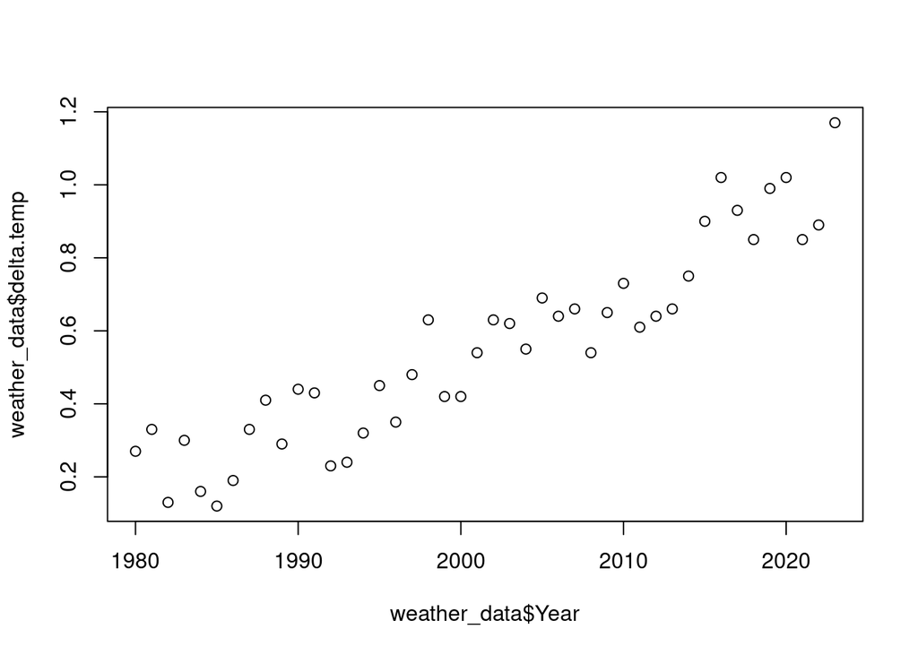

```r
plot(weather_data$Year, weather_data$delta.temp)
```